# answers

```python
import numpy as np
import pandas as pd
import matplotlib.pyplot as plt
```

## Section 1 : Calculating the Redshift of Galaxies

The RA and Dec data has been converted from the format $a°b^mc^s$ to $xx^°$

```python
data = pd.read_csv('galaxy.csv')
temp = data['RA J2000.0'].str.split(' ', expand=True)
data['RA J2000.0'] = temp[0].astype(float) + temp[1].astype(float) / 60 + temp[2].astype(float) / 3600
temp = data['Dec J2000.0'].str.split(' ', expand=True)
data['Dec J2000.0'] = temp[0].astype(float) + temp[1].astype(float) / 60 + temp[2].astype(float) / 3600
```

##### Redshift is a phenomenon in which the wavelength of light from an object is stretched, causing it to shift towards the longer (redder) wavelengths of the electromagnetic spectrum. This shift occurs when an object that emits light moves away from the observer, causing the observed light to be stretched due to the Doppler effect.

Finding red shift of galaxies using observed wavelength of H alpha  
$Red shift = λ-λ_{Hα}/λ_{Hα}$

```python
# Calculate the value of red shift
Rest_wl = 6562.8
data['Red shift'] = (data['Observed Wavelength of H-alpha']-Rest_wl)/Rest_wl
```

##### Radial velocity refers to the component of an object's velocity that is directed along the line of sight of an observer.

Now we find the radial velocity of the galaxies  
z = Red shift  
c = speed of light  
$Radialvelocity = z*c$

```python
#calculate the radial velocity of the galaxy
c = 3E5 # km/s
data['Radial velocity'] = data['Red shift']*c
```

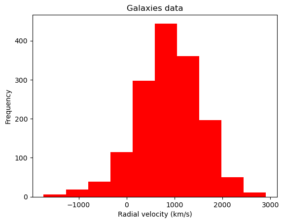

```python
plt.hist(data['Radial velocity'],color= 'r')
plt.xlabel('Radial velocity (km/s)')
plt.ylabel('Frequency')
plt.title('Galaxies data')
plt.show()
```

#### Q1.1. What is the approximate angular size of the galaxy cluster?

##### The angular size of a cluster refers to the apparent size of the cluster as observed from a particular vantage point, typically from Earth. It is measured as an angle and represents the extent of the cluster in the sky.

Here we have used the angular separation formula to find the angular size of the galaxy cluster by taking the angular separation of coordinates of galaxies at the extreme ends of the cluster by taking the minimum and maximum of Right Ascension(RA) at J2000.0 and Declination and J2000.0.

##### RA is analogous to longitude on the Earth's surface, but instead of measuring east and west, it measures eastward around the celestial equator and Dec is analogous to latitude on the Earth's surface, but instead of measuring north and south, it measures angular distance above or below the celestial equator.

To find the angular size we used this formula:-

$cos(θ) = sin(δ_1)*sin(δ_2) + cos(δ_1)*cos(δ_2)*cos(α_1 - α_2)$  
Here, we have converted the values of RA and Dec from degrees to radians during the usage of this formula which could be used in calculation further.

```python
max_ra = data['RA J2000.0'].max()
min_ra = data['RA J2000.0'].min()
max_dec = data['Dec J2000.0'].max()
min_dec = data['Dec J2000.0'].min()
angular_size = np.arccos(np.sin(np.deg2rad(max_dec)) * np.sin(np.deg2rad(min_dec)) +
                         np.cos(np.deg2rad(max_dec)) * np.cos(np.deg2rad(min_dec)) *
                         np.cos(np.deg2rad(max_ra - min_ra)))
# Calculate angular size (in degrees)
angular_size_degrees = np.rad2deg(angular_size)

print("Approximate Angular Size of the Galaxy Cluster:", angular_size_degrees, "degrees")
```

```
Approximate Angular Size of the Galaxy Cluster: 31.543485617621428 degrees
```

#### Q1.2. Can you comment anything about the rotation of the galaxies around the center of the cluster.

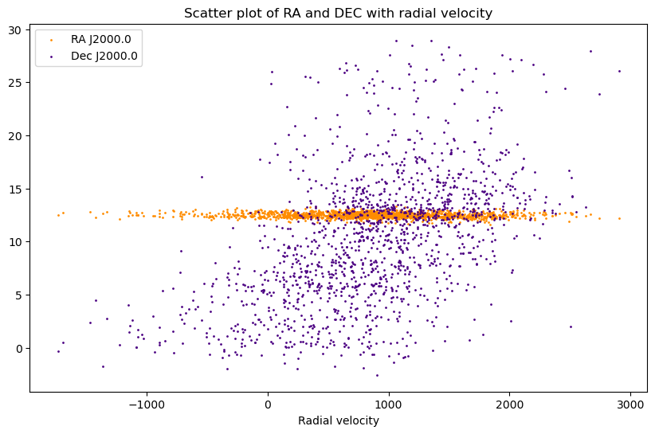

```python
plt.figure(figsize=(10,6)) # figsize specifies the size of the plot
plt.scatter(data['Radial velocity'],data['RA J2000.0'],s = 1, color='darkorange',label='RA J2000.0')
plt.scatter(data['Radial velocity'],data['Dec J2000.0'],s = 1,color='indigo',label='Dec J2000.0') # You can plot more than one scatter plots
                                                                   #  at once same as normal plots
plt.xlabel('Radial velocity')
plt.title('Scatter plot of RA and DEC with radial velocity')
plt.legend()
```

## Section 2 : Calibrating Cepheids Data

```python
gaia_data = pd.read_csv('gaia.csv')
```

$Distance = 1/Parallex$ (in arcsec)

```python
# Convert parallax to distance (parallax is in milliarcseconds)
distance = 1 / (gaia_data['parallax'] * 0.001)  # Convert milliarcseconds to arcseconds
```

```python
# Calculate log10 time period
log_period = np.log10(gaia_data['time period'])
```

$M = m - 5(log(d)-1)$

M is an absolute magnitude which is the magnitude of the object from a distance of 10parsec  
m is mean apparent magnitude  
d is the distance between observer and source

```python
# Calculate absolute magnitude using distance and apparent magnitude
absolute_magnitude = gaia_data['mean apparent magnitude'] - 5 * np.log10(distance) + 5
```

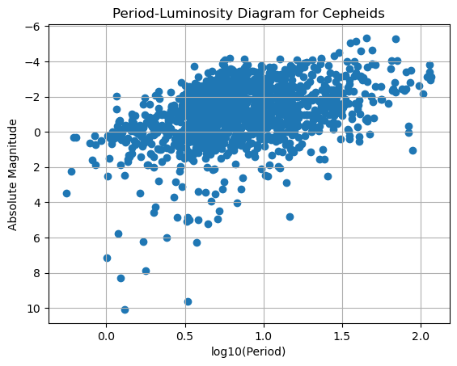

```python
# Plot M vs log10(P)
plt.scatter(log_period, absolute_magnitude, label='Observational Data')
ax = plt.gca()
ax.invert_yaxis()
plt.xlabel('log10(Period)')
plt.ylabel('Absolute Magnitude')
plt.title('Period-Luminosity Diagram for Cepheids')
plt.grid(True)
```

```python
# Fit a polynomial regression line
coefficients = np.polyfit(log_period, absolute_magnitude, 1)
alpha, beta = coefficients[0], coefficients[1]
```

After plotting the graph of absolute magnitude with respect to $log_{10}P$ if we compare the the below equation with $y = mx + c$

$M = α_{10}(P(in days)) + β$  
Therefore, the slope of the line is $α$ and the y-intercept is $β$

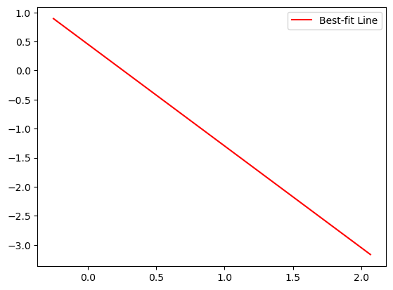

```python
# Plot the best-fit line
x_values = np.linspace(min(log_period), max(log_period), 100)
y_values = alpha * x_values + beta
plt.plot(x_values, y_values, color='red', label='Best-fit Line')

plt.legend()
plt.show()
```

```python
print('Alpha = ', alpha)
print('Beta = ', beta)
```

```
Alpha =  -1.7501625568866073
Beta =  0.4529616510303395
```

## Section 3 : Getting the distances to our galaxies

Considering outliers as the galaxies with magnitudes less than 20

```python
cepheid_data = pd.read_csv('cepheid.csv')
# Here galaxies having magnitudes less than 20 are considered outliers and are removed from data
cepheid_data = cepheid_data[cepheid_data['Apparent Magnitude'] >= 20]
```

$M = α_{10}(P(in days)) + β$

Here, we use the values of alpha and beta obtained in the previous section

```python
cepheid_data['Absolute Magnitude'] = alpha * np.log10(cepheid_data['Period']) + beta
```

$M = m - 5(log(d)-1)$

```python
cepheid_data['Distance (parsecs)'] = 10**((cepheid_data['Apparent Magnitude'] - cepheid_data['Absolute Magnitude'] + 5) / 5)
```

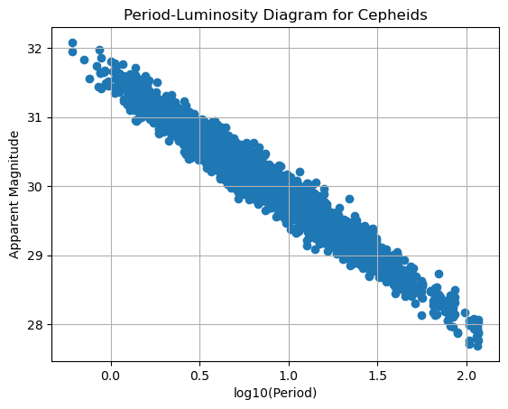

```python
plt.scatter(np.log10(cepheid_data['Period']), cepheid_data['Apparent Magnitude'], label='Observational Data')
plt.xlabel('log10(Period)')
plt.ylabel('Apparent Magnitude')
plt.title('Period-Luminosity Diagram for Cepheids')
plt.grid(True)
```

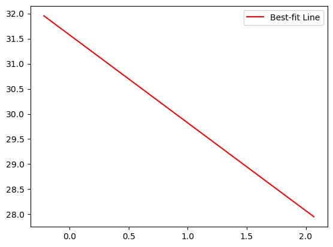

```python
coefficients = np.polyfit(np.log10(cepheid_data['Period']), cepheid_data['Apparent Magnitude'], 1)
alpha, beta = coefficients[0], coefficients[1]
x_values = np.linspace(min(np.log10(cepheid_data['Period'])), max(np.log10(cepheid_data['Period'])), 100)
y_values = alpha * x_values + beta
plt.plot(x_values, y_values, color='red', label='Best-fit Line')

plt.legend()
plt.show()
```

```python
print(cepheid_data[['Cepheid ID', 'Galaxy_ID', 'Distance (parsecs)']])
```

```
     Cepheid ID  Galaxy_ID  Distance (parsecs)
1     XYZ819204    NGC4379        1.656349e+07
2     XYZ589831  PGC039619        1.737821e+07
3     XYZ327693  PGC043108        1.479703e+07
4     XYZ688142    NGC4621        1.842056e+07
5     XYZ425999  PGC040411        1.884727e+07
...         ...        ...                 ...
4995  XYZ940768  AGC229053        1.552498e+07
4996  XYZ383719     IC3413        1.546214e+07
4997  XYZ219884  PGC042566        1.644048e+07
4998  XYZ416499  AGC227975        1.797709e+07
4999  XYZ547574   UGC07841        1.828584e+07

[4525 rows x 3 columns]
```

## Section 4 : Getting the Hubble's Constant

$v = H_0*d$  
where v is the recession velocity i.e velocity of galaxies moving away from the observer  
d is the instantaneous distance between source and the observer space.

```python
H0 = 70 # km/s/Mpc
data['Distance'] = np.abs(data['Radial velocity']/H0)
```

Here we have caculated the mean and standard deviation of radial velocity and distance using numpy function "np.mean()" and "np.std()" respectively.

```python
velocity_mean = np.mean(data['Radial velocity'])
velocity_std = np.std(data['Radial velocity'])
distance_mean = np.mean(data['Distance'])
distance_std = np.std(data['Distance'])
```

The gaussian of is plotted using following code

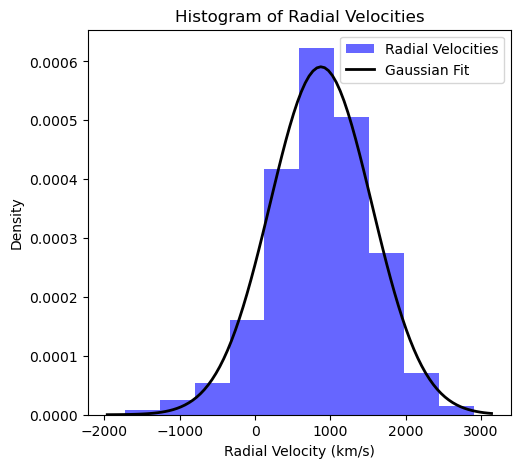

```python
# Plot histograms with fitted Gaussians for velocity and distance data
plt.figure(figsize=(12, 5))

# Histogram and fitted Gaussian for radial velocities
plt.subplot(1, 2, 1)
plt.hist(data['Radial velocity'], bins=10, density=True, alpha=0.6, color='b', label='Radial Velocities')
xmin, xmax = plt.xlim()
x_velocity = np.linspace(xmin, xmax, 100)
p_velocity = (1 / (velocity_std * np.sqrt(2 * np.pi))) * np.exp(-0.5 * ((x_velocity - velocity_mean) / velocity_std)**2)
plt.plot(x_velocity, p_velocity, 'k', linewidth=2, label='Gaussian Fit')
plt.title('Histogram of Radial Velocities')
plt.xlabel('Radial Velocity (km/s)')
plt.ylabel('Density')
plt.legend()
```

```python
# Print the mean and standard deviation of radial velocities and distances
print('Mean Radial Velocity: ',velocity_mean, 'km/s', 'Standard Deviation: ',velocity_std, ' km/s')
print('Mean Distance: ' ,distance_mean, 'Mpc', 'Standard Deviation: ' ,distance_mean, ' Mpc')
```

```
Mean Radial Velocity:  874.0897370131784 km/s Standard Deviation:  675.0501208390568  km/s
Mean Distance:  13.634199733031561 Mpc Standard Deviation:  13.634199733031561  Mpc
```

```python
# Calculate Hubble Constant (H) from mean radial velocity and mean distance
hubble_constant = velocity_mean / distance_mean
print('Estimated Hubble Constant (H): ', hubble_constant, 'km/s/Mpc')
```

```
Estimated Hubble Constant (H):  64.11008743663349 km/s/Mpc
```

```python
H0 = 70
# Calculate percentage error
percentage_error = np.abs((hubble_constant - H0) / H0) * 100
print(percentage_error)
```

```
8.414160804809297
```

#### Q4.1 Compare the value of that you got H from the standard H0 commonly accepted today. The estimate that you got - is it the same (within error margins), higher or lower than the value of H0

The estimate for hubble constant obtained is lower than the standard value i.e $H = 64.11$ considering $H_0 = 70$, with 8.414% error margin

#### Q4.2 What might be the reason behind this difference in values

There could be errors in the values of data obtained through observation. It has been seen that the value of H can vary even based on the region of the universe. More data always results in better results, thus sample space is also a factor in achieving good approximation.

## Section 5 : Dark Matter

#### Q5.1 ESTIMATE the total mass of the Galaxy Cluster. This includes mass due to visible matter as well as dark matter.

To use the virial theorem we need to calculate the value of the Radius of the cluster

Now to calculate the radius we will first find the angular diameter distance(ADD)

$ADD = d/(1+Z)$

where $d$ is the distance of the source and the observer  
$z$ is the Red-shift values  
Here, we take the mean of z and d for the calculation

```python
# Calculate angular diameter distance
angular_diameter_distance = np.mean(data['Distance']) / (1 + np.mean(data['Red shift']))
```

Now we can find the radius using the formula $Radius = ADD*angularsize$

```python
# Calculate radius of the galaxy cluster
radius = angular_diameter_distance * angular_size #mparsecs
print("Radius of the galaxy cluster:", radius, "Mparsecs")
```

```
Radius of the galaxy cluster: 7.484334112475384 Mparsecs
```

Here, we have used Virial's theorem

```python
G = 6.673E-11
radius_0 = radius*3.0857E+15
avg_radial_vel = np.mean(data['Radial velocity'])**2
Total_mass = radius_m*avg_radial_vel/G
```

```python
print('The total mass of the cluster is' , Total_mass)
```

[output not shown]

#### Q5.2 ESTIMATE the visible mass in the galaxy cluster. Use the Mass - Luminosity Relation for Main-Sequence Stars, assuming that it holds well for galaxies too. You may use the Milky Way as a reference.

```python
data['Absolute_Magnitude'] = data['Apparent Mag'] - 5 * np.log10(data['Distance']) + 5
# Convert absolute magnitude to luminosity
data['Luminosity'] = 10 ** (0.4 * (4.83 - data['Absolute_Magnitude']))
```

```python
absolute_magnitude_mw = -21
visible_mass_mw = 2E11*2E30
luminosity_of_mw = 1.1*10E37
```

Mass luminosity relation for main sequence stars is $L = M^{3.5}$

where value 3.5 is specially for Main-sequence stars

Considering $M$ to be a visible mass of the cluster

```python
#calculate mass of visible galaxy
visible_cluster_mass = visible_mass_mw*((np.mean(data['Luminosity'])/luminosity_of_mw)**(1/3.5))
```

```python
print(visible_cluster_mass)
```

```
9.661576935979844e+29
```

#### Q5.3 What is the fraction of the total mass of the galaxy cluster that is actually in the form of Dark Matter

```python
Frac_of_visible_mass = visible_cluster_mass/Total_mass
Frac_of_Dark_matter = 1 - Frac_of_visible_mass
```

```python
print(Frac_of_Dark_matter)
```

```
0.7906500486429542
```

Around 0.80 amount of total mass is in the form of dark matter.